# Workshop: Introduction to Queuing Theory

Author

Mick Cooney mickcooney@gmail.com

Published

March 1, 2026

# 1 Introduction and Basic Concepts

## 1.1 What is Queueing Theory?

Queueing theory is the mathematical study of waiting lines (queues). It provides analytical tools to predict and optimize the performance of systems where customers (or jobs, packets, vehicles, etc.) arrive to receive service.

**Real-world applications include:**

- **Banking**: Teller lines, ATM networks
- **Healthcare**: Emergency departments, clinic appointments
- **Call centers**: Customer service agents
- **Manufacturing**: Production lines, machine shops
- **Computing**: Server loads, network routers, job scheduling
- **Transportation**: Toll booths, airport security, traffic lights

Queueing theory helps answer questions like:

- How many servers do I need to meet service level targets?
- What is the average wait time customers will experience?
- How does variability in service times affect performance?
- Is it better to have one pooled queue or separate queues?

## 1.2 Workshop Materials

All code and materials for this workshop are available on GitHub: **https://github.com/kaybenleroll/data_workshops**

This workshop requires the following R packages:

- `queueing`: Analytical queue calculations
- `simmer`: Discrete-event simulation
- `simmer.plot`: Visualization for simmer
- `tidyverse`: Data manipulation and visualization
- `cowplot`: Plot themes and arrangement

## 1.3 Core Components of a Queueing System

Every queueing system has six components:

### 1.3.1 Arrival Process

How customers enter the system:

- **Rate**: How frequently arrivals occur (λ = lambda)
- **Pattern**: Regular, random (Poisson), scheduled
- **Batch vs. individual**: Do customers arrive one at a time or in groups?

### 1.3.2 Service Process

How long service takes:

- **Rate**: How quickly service completes (μ = mu)
- **Distribution**: Constant, exponential, general
- **Servers**: How many are working in parallel?

### 1.3.3 Number of Servers (c)

- Single server (c = 1)
- Multiple servers in parallel (c > 1)

### 1.3.4 Queue Capacity (K)

- **Infinite**: Queue can grow without bound
- **Finite**: Maximum queue length (blocking or balking)

### 1.3.5 Population Size (N)

- **Infinite**: Unlimited potential customers
- **Finite**: Fixed customer pool (e.g., machines in a shop)

### 1.3.6 Queue Discipline

The rule for selecting who gets served next:

- **FIFO** (First-In-First-Out): Most common
- **LIFO** (Last-In-First-Out): Stack-like
- **Priority**: Different classes served preferentially
- **Processor sharing**: All customers served simultaneously

## 1.4 Kendall Notation (A/B/c/K/N/D)

Queueing systems are described using **Kendall notation**:

$$\text{A / B / c / K / N / D}$$

Where:

- **A**: Arrival process distribution
- **B**: Service time distribution
- **c**: Number of servers
- **K**: System capacity (default: ∞)
- **N**: Population size (default: ∞)
- **D**: Queue discipline (default: FIFO)

**Common distribution codes:**

- **M**: Markovian (exponential, memoryless)
- **D**: Deterministic (constant)
- **G**: General (arbitrary distribution)
- **Er**: Erlang distribution
- **H**: Hyperexponential

**Examples:**

- **M/M/1**: Poisson arrivals, exponential service, 1 server
- **M/M/c**: Poisson arrivals, exponential service, c servers
- **M/D/1**: Poisson arrivals, constant service, 1 server
- **M/G/1**: Poisson arrivals, general service distribution, 1 server

When K, N, and D are omitted, they default to ∞, ∞, and FIFO.

# 2 Foundational Probability

## 2.1 The Poisson Process

A **Poisson process** models random arrivals at a constant average rate λ (lambda). Key properties:

- Arrivals occur independently
- Arrival rate is constant over time
- Exactly one arrival occurs in an infinitesimal time interval
- **Memoryless**: Past arrivals don’t affect future arrivals

The number of arrivals in time interval $t$ follows a Poisson distribution:

$$P(N(t) = n) = \frac{(\lambda t)^n e^{-\lambda t}}{n!}$$

With mean and variance both equal to $\lambda t$.

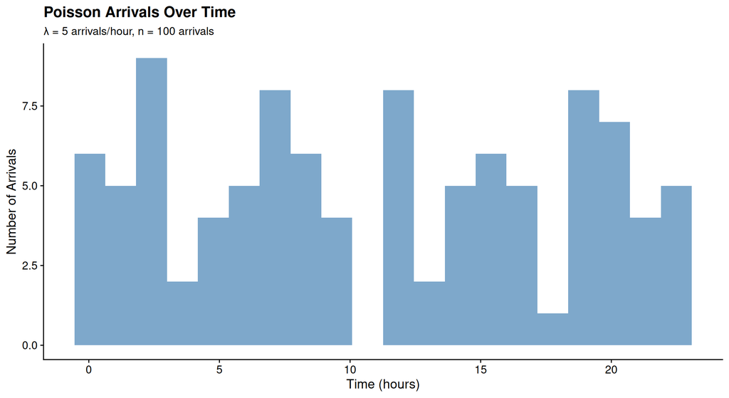

```r
lambda <- 5  # 5 arrivals per hour

arrivals <- simulate_poisson_arrivals(n = 100, lambda = lambda)

ggplot(tibble(arrival_time = arrivals), aes(x = arrival_time)) +
  geom_histogram(bins = 20, fill = "steelblue", alpha = 0.7) +
  labs(
    title = "Poisson Arrivals Over Time",
    subtitle = glue("λ = {lambda} arrivals/hour, n = 100 arrivals"),
    x = "Time (hours)",
    y = "Number of Arrivals"
    )
```

## 2.2 The Exponential Distribution

If arrivals follow a Poisson process with rate λ, then the **time between consecutive arrivals** (interarrival time) follows an exponential distribution:

$$f(t) = \lambda e^{-\lambda t}, \quad t \geq 0$$

With mean $E[T] = 1/\lambda$ and variance $Var[T] = 1/\lambda^2$.

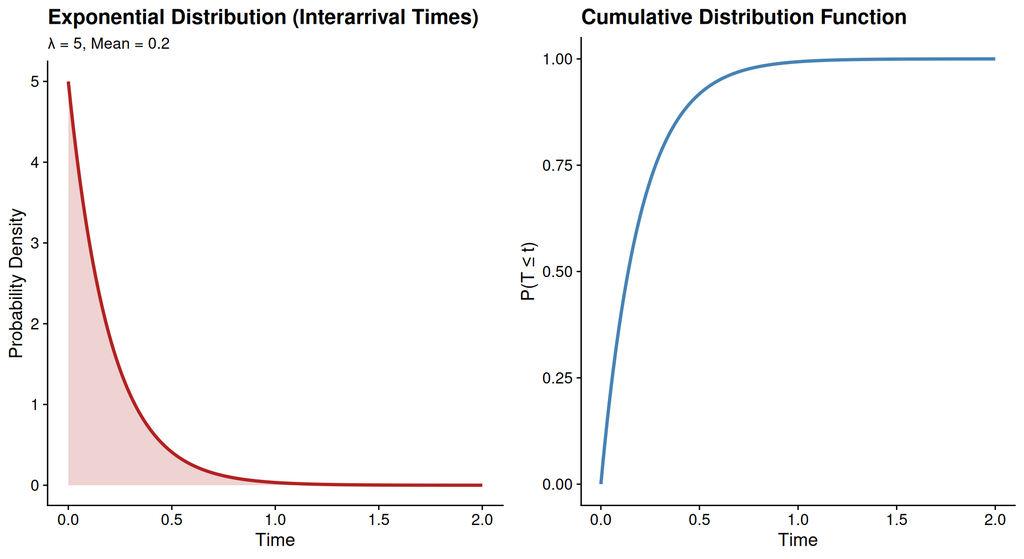

```r
lambda <- 5
t_seq <- seq(0, 2, length.out = 200)

exponential_tbl <- tibble(
  t = t_seq,
  density = dexp(t, rate = lambda),
  cumulative = pexp(t, rate = lambda)
  )

density_plot <- ggplot(exponential_tbl, aes(x = t, y = density)) +
  geom_line(colour = "firebrick", linewidth = 1.2) +
  geom_area(fill = "firebrick", alpha = 0.2) +
  labs(
    title = "Exponential Distribution (Interarrival Times)",
    subtitle = glue("λ = {lambda}, Mean = {round(1/lambda, 2)}"),
    x = "Time",
    y = "Probability Density"
    )

cdf_plot <- ggplot(exponential_tbl, aes(x = t, y = cumulative)) +
  geom_line(colour = "steelblue", linewidth = 1.2) +
  labs(
    title = "Cumulative Distribution Function",
    x = "Time",
    y = "P(T ≤ t)"
    )

plot_grid(density_plot, cdf_plot, ncol = 2)
```

### 2.2.1 Memoryless Property

The exponential distribution has a unique property: it is **memoryless**. If a customer has been waiting for time $s$, the remaining wait time has the same distribution as the original wait:

$$P(T > s + t \mid T > s) = P(T > t)$$

This means “time already spent waiting doesn’t reduce future expected wait.”

```r
lambda <- 5
n_samples <- 10000

all_waits <- rexp(n_samples, rate = lambda)

s_cutoff <- 0.1
conditional_waits <- all_waits[all_waits > s_cutoff] - s_cutoff

write_lines(
  glue(
    "Unconditional wait: Mean = {round(mean(all_waits), 3)}\n",
    "Conditional wait (given T > {s_cutoff}): Mean = {round(mean(conditional_waits), 3)}\n",
    "Theoretical mean: {round(1/lambda, 3)}"
    ),
  stdout()
  )
```

```
Unconditional wait: Mean = 0.201
Conditional wait (given T > 0.1): Mean = 0.202
Theoretical mean: 0.2
```

## 2.3 Other Service Time Distributions

While exponential service is common in theory, real systems often have different distributions:

- **Deterministic (constant)**: Automated systems, toll booths
- **Erlang**: Sum of k exponential stages (less variable than exponential)
- **Hyperexponential**: Mixture of exponentials (more variable)
- **General**: Any distribution characterized by mean and variance

# 3 Key Performance Metrics

## 3.1 Utilization (ρ)

**Utilization** measures the fraction of time servers are busy:

$$\rho = \frac{\lambda}{c \mu}$$

Where:

- λ = arrival rate
- μ = service rate per server
- c = number of servers

**Interpretation:**

- ρ = 0.7 means servers busy 70% of time
- ρ < 1 is required for system stability
- ρ approaching 1 causes explosive queue growth

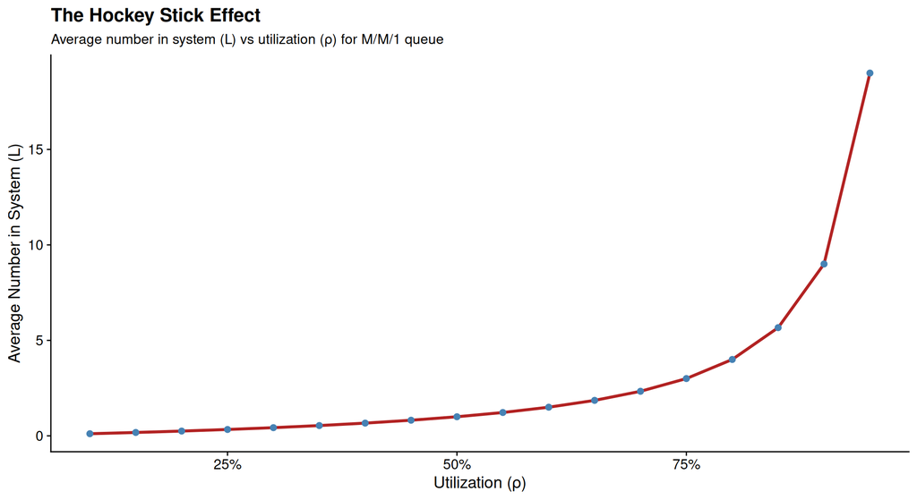

```r
rho_values <- seq(0.1, 0.95, by = 0.05)
L_values <- rho_values / (1 - rho_values)  # M/M/1 formula

ggplot(tibble(rho = rho_values, L = L_values), aes(x = rho, y = L)) +
  geom_line(colour = "firebrick", linewidth = 1.2) +
  geom_point(colour = "steelblue", size = 2) +
  scale_x_continuous(labels = percent) +
  labs(
    title = "The Hockey Stick Effect",
    subtitle = "Average number in system (L) vs utilization (ρ) for M/M/1 queue",
    x = "Utilization (ρ)",
    y = "Average Number in System (L)"
    )
```

## 3.2 Queue Lengths

- **L**: Average number of customers in the system (queue + service)
- **Lq**: Average number of customers waiting in queue (not being served)

Relationship: $L = L_q + \rho$ (for single-server queues)

## 3.3 Waiting Times

- **W**: Average time a customer spends in the system (sojourn time)
- **Wq**: Average time a customer spends waiting in queue

Relationship: $W = W_q + 1/\mu$ (wait + service)

## 3.4 Little’s Law

The most fundamental result in queueing theory:

$$L = \lambda W \quad \text{and} \quad L_q = \lambda W_q$$

**Interpretation**: Average number in system equals arrival rate times average time in system.

**Why it matters**:

- Universal: Applies to any stable queueing system
- Requires no assumptions about distributions
- Connects length and time metrics

```r
lambda <- 4
mu <- 5

metrics <- calculate_mm1_metrics(lambda, mu)

write_lines(
  glue(
    "M/M/1 Queue with λ = {lambda}, μ = {mu}\n\n",
    "L = {round(metrics$L, 3)}\n",
    "λ × W = {lambda} × {round(metrics$W, 3)} = {round(lambda * metrics$W, 3)}\n\n",
    "Lq = {round(metrics$Lq, 3)}\n",
    "λ × Wq = {lambda} × {round(metrics$Wq, 3)} = {round(lambda * metrics$Wq, 3)}\n\n",
    "Little's Law verified!"
    ),
  stdout()
  )
```

```
M/M/1 Queue with λ = 4, μ = 5

L = 4
λ × W = 4 × 1 = 4

Lq = 3.2
λ × Wq = 4 × 0.8 = 3.2

Little's Law verified!
```

# 4 M/M/1 Queue Analysis

## 4.1 Model Description

The **M/M/1 queue** is the simplest and most important queueing model:

- **M**: Poisson arrivals (Markovian, exponential interarrival times)
- **M**: Exponential service times
- **1**: Single server

Despite its simplicity, the M/M/1 model provides intuition for more complex systems and is exactly solvable.

## 4.2 Steady-State Results

For an M/M/1 queue with arrival rate λ and service rate μ:

| Metric | Formula | Interpretation |
| --- | --- | --- |
| Utilization | $\rho = \lambda/\mu$ | Fraction of time server busy |
| Prob(n customers) | $P_n = (1-\rho)\rho^n$ | Geometric distribution |
| Avg in system | $L = \frac{\rho}{1-\rho}$ | Total customers present |
| Avg in queue | $L_q = \frac{\rho^2}{1-\rho}$ | Waiting customers only |
| Avg time in system | $W = \frac{1}{\mu - \lambda}$ | Total time per customer |
| Avg wait time | $W_q = \frac{\rho}{\mu - \lambda}$ | Queue wait only |
| Prob(empty) | $P_0 = 1 - \rho$ | System is idle |

**Stability condition**: $\lambda < \mu$ (equivalently $\rho < 1$)

## 4.3 Example: Bank Teller

A small bank branch has one teller. Customers arrive at rate 8 per hour. Service takes 6 minutes on average.

```r
lambda_bank <- 8      # customers per hour
mu_bank <- 60 / 6     # 60/6 = 10 customers per hour

metrics_bank <- calculate_mm1_metrics(lambda_bank, mu_bank)

write_lines(
  glue(
    "=== BANK TELLER ANALYSIS ===\n\n",
    "Arrival rate: {lambda_bank} customers/hour\n",
    "Service rate: {mu_bank} customers/hour\n",
    "Average service time: {round(1/mu_bank * 60, 1)} minutes\n\n",
    "PERFORMANCE METRICS:\n",
    "Utilization: {percent(metrics_bank$rho, accuracy = 0.1)}\n",
    "Avg customers in system: {round(metrics_bank$L, 2)}\n",
    "Avg customers in queue: {round(metrics_bank$Lq, 2)}\n",
    "Avg time in system: {round(metrics_bank$W * 60, 1)} minutes\n",
    "Avg wait time: {round(metrics_bank$Wq * 60, 1)} minutes\n",
    "Prob(empty system): {percent(metrics_bank$P0, accuracy = 0.1)}"
    ),
  stdout()
  )
```

```
=== BANK TELLER ANALYSIS ===

Arrival rate: 8 customers/hour
Service rate: 10 customers/hour
Average service time: 6 minutes

PERFORMANCE METRICS:
Utilization: 80.0%
Avg customers in system: 4
Avg customers in queue: 3.2
Avg time in system: 30 minutes
Avg wait time: 24 minutes
Prob(empty system): 20.0%
```

**Interpretation**: Customers wait an average of 24 minutes in queue, and the teller is busy 80% of the time. The queue has an average of 3.2 waiting customers.

## 4.4 Sensitivity Analysis

What happens if arrival rate increases to 9 customers per hour?

```r
lambda_high <- 9
metrics_high <- calculate_mm1_metrics(lambda_high, mu_bank)

comparison_tbl <- tibble(
  scenario = c("Baseline", "Increased Arrivals"),
  lambda = c(lambda_bank, lambda_high),
  rho = c(metrics_bank$rho, metrics_high$rho),
  Lq = c(metrics_bank$Lq, metrics_high$Lq),
  Wq_min = c(metrics_bank$Wq * 60, metrics_high$Wq * 60)
  )

print(comparison_tbl)
```

```
# A tibble: 2 × 5
  scenario           lambda   rho    Lq Wq_min
  <chr>               <dbl> <dbl> <dbl>  <dbl>
1 Baseline                8   0.8   3.2     24
2 Increased Arrivals      9   0.9   8.1     54
```

**Key insight**: A 12.5% increase in arrival rate (8→9) causes wait time to more than double! This is the “hockey stick effect” — performance degrades rapidly as ρ → 1.

## 4.5 State Probabilities

The M/M/1 queue has a geometric steady-state distribution:

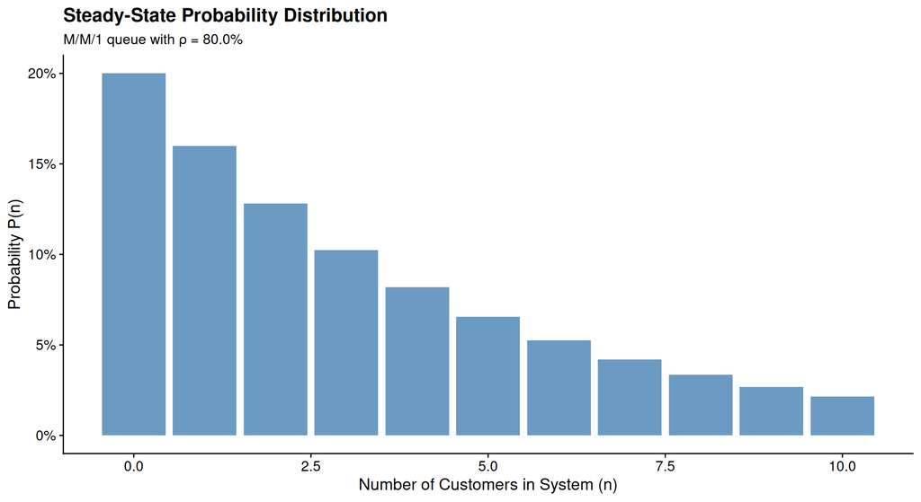

```r
n_states <- 0:10
rho <- metrics_bank$rho
prob_n <- (1 - rho) * rho^n_states

ggplot(tibble(n = n_states, prob = prob_n), aes(x = n, y = prob)) +
  geom_bar(stat = "identity", fill = "steelblue", alpha = 0.8) +
  scale_y_continuous(labels = percent) +
  labs(
    title = "Steady-State Probability Distribution",
    subtitle = glue("M/M/1 queue with ρ = {percent(rho, accuracy = 0.1)}"),
    x = "Number of Customers in System (n)",
    y = "Probability P(n)"
    )
```

# 5 M/M/c Queue (Multi-Server)

## 5.1 Model Description

The **M/M/c queue** extends M/M/1 to multiple servers working in parallel:

- Single queue, c servers
- Customers form one line and go to next available server
- Same arrival and service rates as M/M/1

Common applications: call centers, bank branches, checkout lanes.

## 5.2 Key Results

For M/M/c with arrival rate λ, service rate μ per server, and c servers:

- **Per-server utilization**: $\rho = \lambda / (c\mu)$
- **Erlang C formula** gives probability a customer must wait:

$$C(c, \rho c) = \frac{P_0 (c\rho)^c / c!}{1 - \rho}$$

Where $P_0$ is found by normalizing probabilities to sum to 1.

- **Average wait time**: $W_q = \frac{C(c, \rho c)}{c\mu - \lambda}$
- **Average time in system**: $W = W_q + 1/\mu$

## 5.3 Example: Call Center Staffing

A call center receives 60 calls per hour. Each call takes 5 minutes on average. Management wants to know how many agents are needed.

```r
lambda_cc <- 60        # calls per hour
mu_cc <- 60 / 5        # 12 calls per hour per agent

c_values <- 6:10

comparison_lst <- map(c_values, function(c) {
  metrics <- calculate_mmc_metrics(lambda_cc, mu_cc, c)
  tibble(
    servers = c,
    rho = metrics$rho,
    Pw = metrics$Pw,
    Wq_seconds = metrics$Wq * 3600,
    L = metrics$L
    )
  }) |>
  bind_rows()

print(comparison_lst)
```

```
# A tibble: 5 × 5
  servers   rho     Pw Wq_seconds     L
    <int> <dbl>  <dbl>      <dbl> <dbl>
1       6 0.833 0.588      176.    7.94
2       7 0.714 0.324       48.6   5.81
3       8 0.625 0.167       16.7   5.28
4       9 0.556 0.0805       6.04  5.10
5      10 0.5   0.0361       2.17  5.04
```

## 5.4 The Pooling Effect

Why is one queue with c servers better than c separate M/M/1 queues?

**Pooling reduces variability**: When servers share a queue, idle capacity can be used immediately. With separate queues, an idle server can’t help other queues.

```r
lambda_total <- 15  # total arrivals per hour
mu <- 5             # service rate per server
c <- 4              # number of servers

pooled_metrics <- calculate_mmc_metrics(lambda_total, mu, c)

lambda_each <- lambda_total / c
separate_metrics <- calculate_mm1_metrics(lambda_each, mu)

write_lines(
  glue(
    "=== POOLING VS SEPARATE QUEUES ===\n\n",
    "Scenario: {c} servers, {lambda_total} total arrivals/hour\n\n",
    "POOLED (M/M/{c}):\n",
    "  Avg wait time: {round(pooled_metrics$Wq * 60, 2)} minutes\n",
    "  Avg in queue: {round(pooled_metrics$Lq, 2)}\n\n",
    "SEPARATE (4x M/M/1):\n",
    "  Avg wait time: {round(separate_metrics$Wq * 60, 2)} minutes\n",
    "  Avg in queue: {round(separate_metrics$Lq, 2)}\n\n",
    "Improvement: {percent((separate_metrics$Wq - pooled_metrics$Wq) / separate_metrics$Wq)}"
    ),
  stdout()
  )
```

```
=== POOLING VS SEPARATE QUEUES ===

Scenario: 4 servers, 15 total arrivals/hour

POOLED (M/M/4):
  Avg wait time: 6.11 minutes
  Avg in queue: 1.53

SEPARATE (4x M/M/1):
  Avg wait time: 36 minutes
  Avg in queue: 2.25

Improvement: 83%
```

# 6 M/D/1 Queue (Deterministic Service)

## 6.1 Model Description

The **M/D/1 queue** has:

- Poisson arrivals (same as M/M/1)
- **Deterministic (constant) service time**
- Single server

Applications: Automated systems, toll booths with electronic payment, some manufacturing processes.

## 6.2 Key Results

For M/D/1 with arrival rate λ and service time $d = 1/\mu$:

| Metric | Formula | vs M/M/1 |
| --- | --- | --- |
| Utilization | $\rho = \lambda/\mu$ | Same |
| Avg in queue | $L_q = \frac{\rho^2}{2(1-\rho)}$ | Exactly half |
| Avg wait time | $W_q = \frac{\rho}{2\mu(1-\rho)}$ | Exactly half |

**Key insight**: Eliminating service time variability (going from exponential to deterministic) cuts queue length in half!

## 6.3 Example: Toll Booth Comparison

Compare human operators (variable service, ~30 sec average) to automated system (fixed 30 sec).

```r
lambda_toll <- 100    # vehicles per hour
service_time <- 30 / 3600  # 30 seconds in hours
mu_toll <- 1 / service_time

mm1_metrics <- calculate_mm1_metrics(lambda_toll, mu_toll)
md1_metrics <- calculate_md1_metrics(lambda_toll, mu_toll)

rho <- lambda_toll / mu_toll

write_lines(
  glue(
    "=== TOLL BOOTH COMPARISON ===\n\n",
    "Arrival rate: {lambda_toll} vehicles/hour\n",
    "Service time: 30 seconds\n",
    "Utilization: {percent(rho, accuracy = 0.1)}\n\n",
    "HUMAN OPERATORS (M/M/1 - Variable Service):\n",
    "  Avg vehicles in queue: {round(mm1_metrics$Lq, 2)}\n",
    "  Avg wait time: {round(mm1_metrics$Wq * 3600, 1)} seconds\n\n",
    "AUTOMATED (M/D/1 - Fixed Service):\n",
    "  Avg vehicles in queue: {round(md1_metrics$Lq, 2)}\n",
    "  Avg wait time: {round(md1_metrics$Wq * 3600, 1)} seconds\n\n",
    "Reduction: {percent((mm1_metrics$Lq - md1_metrics$Lq) / mm1_metrics$Lq)}"
    ),
  stdout()
  )
```

```
=== TOLL BOOTH COMPARISON ===

Arrival rate: 100 vehicles/hour
Service time: 30 seconds
Utilization: 83.3%

HUMAN OPERATORS (M/M/1 - Variable Service):
  Avg vehicles in queue: 4.17
  Avg wait time: 150 seconds

AUTOMATED (M/D/1 - Fixed Service):
  Avg vehicles in queue: 2.08
  Avg wait time: 75 seconds

Reduction: 50%
```

## 6.4 Visualize M/M/1 vs M/D/1

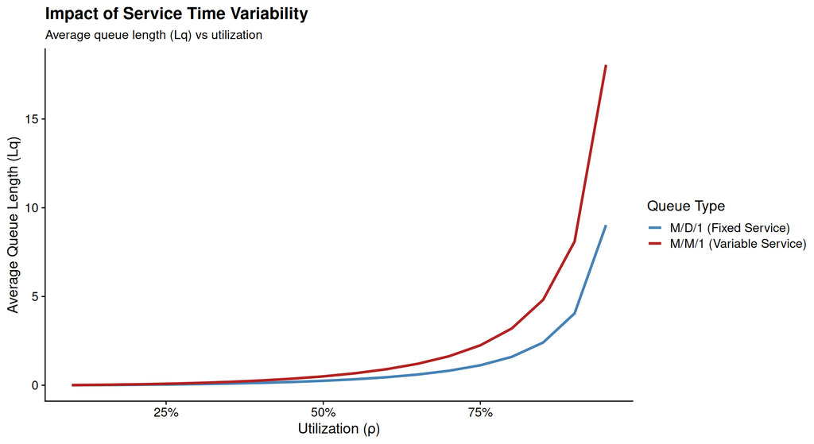

```r
rho_range <- seq(0.1, 0.95, by = 0.05)

comparison_tbl <- tibble(
  rho = rho_range,
  MM1_Lq = rho^2 / (1 - rho),
  MD1_Lq = rho^2 / (2 * (1 - rho))
  ) |>
  pivot_longer(
    cols = c(MM1_Lq, MD1_Lq),
    names_to = "queue_type",
    values_to = "Lq"
    )

ggplot(comparison_tbl, aes(x = rho, y = Lq, colour = queue_type)) +
  geom_line(linewidth = 1.2) +
  scale_x_continuous(labels = percent) +
  scale_colour_manual(
    values = c("MM1_Lq" = "firebrick", "MD1_Lq" = "steelblue"),
    labels = c("MM1_Lq" = "M/M/1 (Variable Service)", "MD1_Lq" = "M/D/1 (Fixed Service)")
    ) +
  labs(
    title = "Impact of Service Time Variability",
    subtitle = "Average queue length (Lq) vs utilization",
    x = "Utilization (ρ)",
    y = "Average Queue Length (Lq)",
    colour = "Queue Type"
    )
```

# 7 M/G/1 Queue (General Service)

## 7.1 Model Description

The **M/G/1 queue** is the most general single-server model:

- Poisson arrivals (same as M/M/1)
- **General service time distribution** (any distribution)
- Only requires mean and variance of service time

This model covers M/M/1 (exponential) and M/D/1 (deterministic) as special cases.

## 7.2 Pollaczek-Khinchine Formula

For M/G/1 with arrival rate λ, mean service time $1/\mu$, and service time variance $\sigma^2$:

$$L_q = \frac{\rho^2(1 + C_s^2)}{2(1 - \rho)}$$

Where $C_s = \sigma / (1/\mu)$ is the **coefficient of variation** of service time.

**Special cases:**

- $C_s = 0$ (deterministic): M/D/1
- $C_s = 1$ (exponential): M/M/1
- $C_s > 1$ (high variability): Worse than M/M/1

**Key insight**: Higher service time variability → longer queues.

## 7.3 Example: Hospital Emergency Department

An ED has Poisson arrivals at rate 1.2 patients per hour. Treatment times are highly variable:

- Mean treatment time: 45 minutes
- Standard deviation: 60 minutes (high variability!)

```r
lambda_ed <- 1.2
treatment_mean <- 45 / 60  # 0.75 hours
treatment_sd <- 60 / 60    # 1.0 hour
treatment_var <- treatment_sd^2

mg1_metrics <- calculate_mg1_metrics(lambda_ed, treatment_mean, treatment_var)

write_lines(
  glue(
    "=== HOSPITAL EMERGENCY DEPARTMENT ===\n\n",
    "Arrival rate: {lambda_ed} patients/hour\n",
    "Mean treatment time: {treatment_mean * 60} minutes\n",
    "SD treatment time: {treatment_sd * 60} minutes\n",
    "Coefficient of variation: {round(mg1_metrics$Cs, 2)}\n\n",
    "PERFORMANCE METRICS:\n",
    "Utilization: {percent(mg1_metrics$rho, accuracy = 0.1)}\n",
    "Avg patients in queue: {round(mg1_metrics$Lq, 2)}\n",
    "Avg wait time: {round(mg1_metrics$Wq * 60, 1)} minutes"
    ),
  stdout()
  )
```

```
=== HOSPITAL EMERGENCY DEPARTMENT ===

Arrival rate: 1.2 patients/hour
Mean treatment time: 45 minutes
SD treatment time: 60 minutes
Coefficient of variation: 1.33

PERFORMANCE METRICS:
Utilization: 90.0%
Avg patients in queue: 11.25
Avg wait time: 562.5 minutes
```

## 7.4 Impact of Reducing Variability

What if the ED standardizes treatment protocols to reduce variability (SD = 30 min)?

```r
treatment_sd_reduced <- 30 / 60  # 0.5 hour
treatment_var_reduced <- treatment_sd_reduced^2

mg1_metrics_reduced <- calculate_mg1_metrics(
  lambda_ed,
  treatment_mean,
  treatment_var_reduced
  )

write_lines(
  glue(
    "BASELINE (SD = 60 min):\n",
    "  Avg wait: {round(mg1_metrics$Wq * 60, 1)} minutes\n",
    "  Cs = {round(mg1_metrics$Cs, 2)}\n\n",
    "REDUCED VARIABILITY (SD = 30 min):\n",
    "  Avg wait: {round(mg1_metrics_reduced$Wq * 60, 1)} minutes\n",
    "  Cs = {round(mg1_metrics_reduced$Cs, 2)}\n\n",
    "Improvement: {percent((mg1_metrics$Wq - mg1_metrics_reduced$Wq) / mg1_metrics$Wq)}"
    ),
  stdout()
  )
```

```
BASELINE (SD = 60 min):
  Avg wait: 562.5 minutes
  Cs = 1.33

REDUCED VARIABILITY (SD = 30 min):
  Avg wait: 292.5 minutes
  Cs = 0.67

Improvement: 48%
```

**Conclusion**: Reducing service time variability improves performance, even without changing the average service time!

# 8 Discrete-Event Simulation with simmer

## 8.1 Introduction to Discrete-Event Simulation

**Why simulate** when we have analytical formulas?

1. **Validation**: Confirm analytical results are correct
2. **Complex scenarios**: Time-varying rates, priorities, finite capacity
3. **Distributions**: Explore beyond exponential service times
4. **Transient behavior**: Startup effects, peak hours

**simmer** is a modern R package for discrete-event simulation (DES).

## 8.2 Building a Basic M/M/1 Simulation

Let’s simulate the bank teller example and compare to analytical results.

```r
lambda <- 8
mu <- 10

customer_trajectory <- trajectory("Customer") |>
  seize("teller", 1) |>
  timeout(function() rexp(1, mu)) |>
  release("teller", 1)

sim_env <- simmer("BankSimulation") |>
  add_resource("teller", capacity = 1) |>
  add_generator("customer", customer_trajectory, function() rexp(1, lambda)) |>
  run(until = 1000)

sim_results <- run_queue_simulation(sim_env, until = 1000, warmup = 100)

write_lines(
  glue(
    "=== SIMULATION RESULTS ===\n\n",
    "Customers served: {sim_results$n_served}\n",
    "Avg wait time: {round(sim_results$avg_wait * 60, 2)} minutes\n",
    "Avg system time: {round(sim_results$avg_system_time * 60, 2)} minutes\n",
    "Utilization: {percent(sim_results$utilization, accuracy = 0.1)}\n",
    "Avg queue length: {round(sim_results$avg_queue_length, 2)}"
    ),
  stdout()
  )
```

```
=== SIMULATION RESULTS ===

Customers served: 7118
Avg wait time: NA minutes
Avg system time: 30.39 minutes
Utilization: 90.2%
Avg queue length: 3.18
```

## 8.3 Comparing Analytical vs Simulated

```r
analytical_metrics <- calculate_mm1_metrics(lambda, mu)

comparison_tbl <- tibble(
  Metric = c("Utilization (ρ)", "Avg in System (L)", "Avg Wait (Wq)", "Avg Time (W)"),
  Analytical = c(
    analytical_metrics$rho,
    analytical_metrics$L,
    analytical_metrics$Wq,
    analytical_metrics$W
    ),
  Simulated = c(
    sim_results$utilization,
    NA,  # We didn't compute L from simulation
    sim_results$avg_wait,
    sim_results$avg_system_time
    ),
  Pct_Diff = percent((Simulated - Analytical) / Analytical, accuracy = 0.1)
  )

print(comparison_tbl, n = Inf)
```

```
# A tibble: 4 × 4
  Metric            Analytical Simulated Pct_Diff
  <chr>                  <dbl>     <dbl> <chr>
1 Utilization (ρ)          0.8     0.902 12.7%
2 Avg in System (L)        4      NA     <NA>
3 Avg Wait (Wq)            0.4    NA     <NA>
4 Avg Time (W)             0.5     0.506 1.3%
```

## 8.4 Visualizing Simulation Output

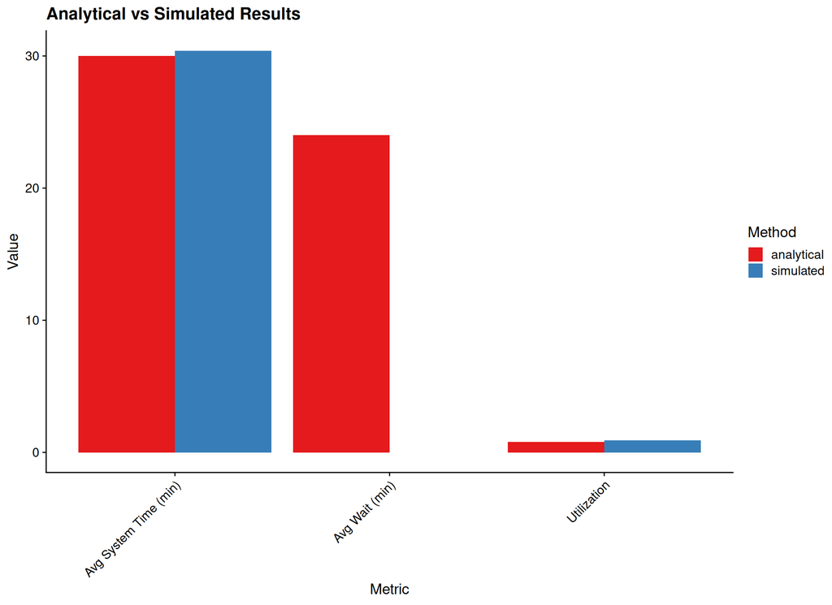

```r
# Create simple comparison visualization
comparison_visual <- tibble(
  metric = c("Utilization", "Avg Wait (min)", "Avg System Time (min)"),
  analytical = c(
    analytical_metrics$rho,
    analytical_metrics$Wq * 60,
    analytical_metrics$W * 60
  ),
  simulated = c(
    sim_results$utilization,
    sim_results$avg_wait * 60,
    sim_results$avg_system_time * 60
  )
)

comparison_visual |>
  pivot_longer(cols = c(analytical, simulated), names_to = "type", values_to = "value") |>
  ggplot(aes(x = metric, y = value, fill = type)) +
  geom_col(position = "dodge") +
  scale_fill_brewer(palette = "Set1") +
  labs(
    title = "Analytical vs Simulated Results",
    x = "Metric",
    y = "Value",
    fill = "Method"
  ) +
  theme(axis.text.x = element_text(angle = 45, hjust = 1))
```

# 9 Advanced Simulation Examples

## 9.1 Multi-Server Simulation (M/M/c)

Extend the simulation to multiple servers.

```r
lambda_cc <- 100
mu_cc <- 12
c_servers <- 10

customer_trajectory_cc <- trajectory("Caller") |>
  seize("agent", 1) |>
  timeout(function() rexp(1, mu_cc)) |>
  release("agent", 1)

sim_env_cc <- simmer("CallCenterSimulation") |>
  add_resource("agent", capacity = c_servers) |>
  add_generator(
    "caller",
    customer_trajectory_cc,
    function() rexp(1, lambda_cc)
    ) |>
  run(until = 100)

sim_results_cc <- run_queue_simulation(sim_env_cc, until = 100, warmup = 10)

analytical_cc <- calculate_mmc_metrics(lambda_cc, mu_cc, c_servers)

write_lines(
  glue(
    "=== CALL CENTER SIMULATION ===\n\n",
    "ANALYTICAL:\n",
    "  Prob(wait): {percent(analytical_cc$Pw, accuracy = 0.1)}\n",
    "  Avg wait: {round(analytical_cc$Wq * 3600, 1)} seconds\n\n",
    "SIMULATED:\n",
    "  Callers served: {sim_results_cc$n_served}\n",
    "  Avg wait: {round(sim_results_cc$avg_wait * 3600, 1)} seconds\n",
    "  Utilization: {percent(sim_results_cc$utilization, accuracy = 0.1)}"
    ),
  stdout()
  )
```

```
=== CALL CENTER SIMULATION ===

ANALYTICAL:
  Prob(wait): 48.8%
  Avg wait: 87.8 seconds

SIMULATED:
  Callers served: 9052
  Avg wait: NA seconds
  Utilization: 86.4%
```

## 9.2 Time-Varying Arrival Rates

Real systems often have time-varying demand (e.g., call centers with peak hours). Rather than implementing time-varying arrivals in the simulation (which requires complex closure handling), we’ll demonstrate the concept with a simple comparison.

```r
# Simulate steady-state with peak hour rate
lambda_peak <- 10
mu <- 5
c <- 3

# Simulate steady-state with off-peak hour rate
lambda_offpeak <- 2

peak_metrics <- calculate_mmc_metrics(lambda_peak, mu, c)
offpeak_metrics <- calculate_mmc_metrics(lambda_offpeak, mu, c)

comparison_tv <- tibble(
  period = c("Off-Peak (2-8am, 5-11pm)", "Peak Hours (8am-5pm)"),
  arrival_rate = c(lambda_offpeak, lambda_peak),
  utilization = c(offpeak_metrics$rho, peak_metrics$rho),
  avg_wait_seconds = c(
    offpeak_metrics$Wq * 3600,
    peak_metrics$Wq * 3600
  ),
  prob_wait = c(offpeak_metrics$Pw, peak_metrics$Pw)
)

write_lines("Time-Varying Demand Analysis (3 agents):", stdout())
```

```
Time-Varying Demand Analysis (3 agents):
```

```r
print(comparison_tv)
```

```
# A tibble: 2 × 5
  period                   arrival_rate utilization avg_wait_seconds prob_wait
  <chr>                           <dbl>       <dbl>            <dbl>     <dbl>
1 Off-Peak (2-8am, 5-11pm)            2       0.133             2.28   0.00825
2 Peak Hours (8am-5pm)               10       0.667           320.     0.444
```

```r
write_lines(
  glue(
    "\nKey insight: With time-varying demand, staffing must account for peak hours.\n",
    "Peak hour utilization is {percent(peak_metrics$rho, accuracy = 0.1)},\n",
    "while off-peak is only {percent(offpeak_metrics$rho, accuracy = 0.1)}."
  ),
  stdout()
)
```

```
Key insight: With time-varying demand, staffing must account for peak hours.
Peak hour utilization is 66.7%,
while off-peak is only 13.3%.
```

# 10 Practical Exercises

## 10.1 Exercise 1: Bank Teller Analysis

A bank teller serves customers at rate 12 per hour. Customers arrive at rate 9 per hour.

**Tasks:**

1. Calculate utilization, average queue length, and average wait time
2. Use the `calculate_mm1_metrics()` function
3. What happens if arrival rate increases to 11 per hour?
4. Validate your results with a simulation

```r
lambda_ex1 <- 9
mu_ex1 <- 12

metrics_ex1 <- calculate_mm1_metrics(lambda_ex1, mu_ex1)

write_lines(
  glue(
    "Exercise 1 Solution:\n",
    "Utilization: {percent(metrics_ex1$rho, accuracy = 0.1)}\n",
    "Avg in queue: {round(metrics_ex1$Lq, 2)}\n",
    "Avg wait: {round(metrics_ex1$Wq * 60, 1)} minutes"
    ),
  stdout()
  )
```

```
Exercise 1 Solution:
Utilization: 75.0%
Avg in queue: 2.25
Avg wait: 15 minutes
```

## 10.2 Exercise 2: Call Center Staffing

A call center receives 80 calls per hour. Each call takes 4 minutes on average. Management wants average wait time under 20 seconds.

**Tasks:**

1. How many agents are needed?
2. Use `calculate_mmc_metrics()` to test different server counts
3. What is the utilization at the optimal staffing level?

```r
lambda_ex2 <- 80
mu_ex2 <- 60 / 4  # 15 calls per hour

target_wait_seconds <- 20

for (c in 6:10) {
  metrics_ex2 <- calculate_mmc_metrics(lambda_ex2, mu_ex2, c)
  wait_seconds <- metrics_ex2$Wq * 3600

  write_lines(
    glue(
      "c = {c}: Wq = {round(wait_seconds, 1)} sec, ",
      "ρ = {percent(metrics_ex2$rho, accuracy = 0.1)}"
      ),
    stdout()
    )

  if (wait_seconds < target_wait_seconds) {
    write_lines(glue("\nOptimal: {c} agents"), stdout())
    break
    }
}
```

```
c = 6: Wq = 256.9 sec, ρ = 88.9%
c = 7: Wq = 59 sec, ρ = 76.2%
c = 8: Wq = 19.9 sec, ρ = 66.7%
Optimal: 8 agents
```

## 10.3 Exercise 3: System Comparison

Compare M/M/1, M/D/1, and M/G/1 (with Cv=1.5) at utilization ρ = 0.75.

**Tasks:**

1. Calculate Lq for each queue type
2. Visualize the comparison using `plot_queue_comparison()`

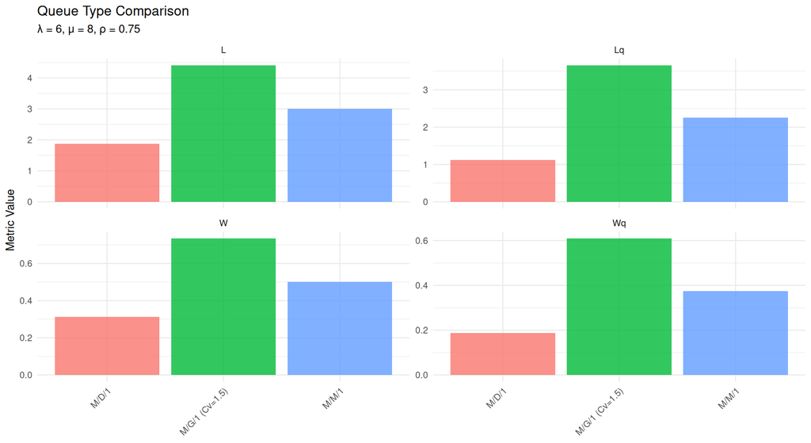

```r
lambda_ex3 <- 6
mu_ex3 <- 8  # ρ = 0.75

plot_queue_comparison(lambda_ex3, mu_ex3, c("MM1", "MD1", "MG1"), service_cv = 1.5)
```

# 11 Summary and Extensions

## 11.1 Key Takeaways

1. **Little’s Law** ($L = \lambda W$) is universal and fundamental
2. **Utilization near 1** causes explosive queue growth (hockey stick effect)
3. **Reducing variability** improves performance even without changing averages
4. **Pooling resources** (M/M/c) is better than separate queues
5. **Simulation validates** analytical results and handles complex scenarios

## 11.2 Beyond This Workshop

### 11.2.1 Networks of Queues

Real systems often involve multiple interconnected queues:

- **Tandem queues**: Output of one queue feeds into another
- **Jackson networks**: Multiple queues with routing
- **Open vs. closed networks**: External arrivals vs. fixed population

### 11.2.2 Advanced Topics

- **Priority queues**: Different customer classes
- **Impatient customers**: Balking (refuse to join) and reneging (leave queue)
- **Batch arrivals/service**: Groups of customers
- **Non-stationary systems**: Time-varying rates and staffing
- **Optimization**: Finding optimal staffing levels

### 11.2.3 Recommended Resources

- **Books**:
  - Kleinrock, “Queueing Systems” (classic reference)
  - Gross & Harris, “Fundamentals of Queueing Theory”
- **R Packages**:
  - `queueing`: Analytical models
  - `simmer`: Discrete-event simulation
  - `queuecomputer`: Queue network simulation